# mutation_data_tidy

Vida Wang

这次偶然课题需要用到突变相关数据，在这做一下简单的总结，抛砖引玉。

癌症相关数据最近都是从[FIREHOSE](http://gdac.broadinstitute.org/runs/)上下载的，第一次发现突变数据并不是按照矩阵形式存储的，还需要自己整理清洗数据(这就很麻烦嘛…),为了方便以后的使用，将整个流程做一下梳理。

我们先看一下原始下载的数据是这介个样子的:

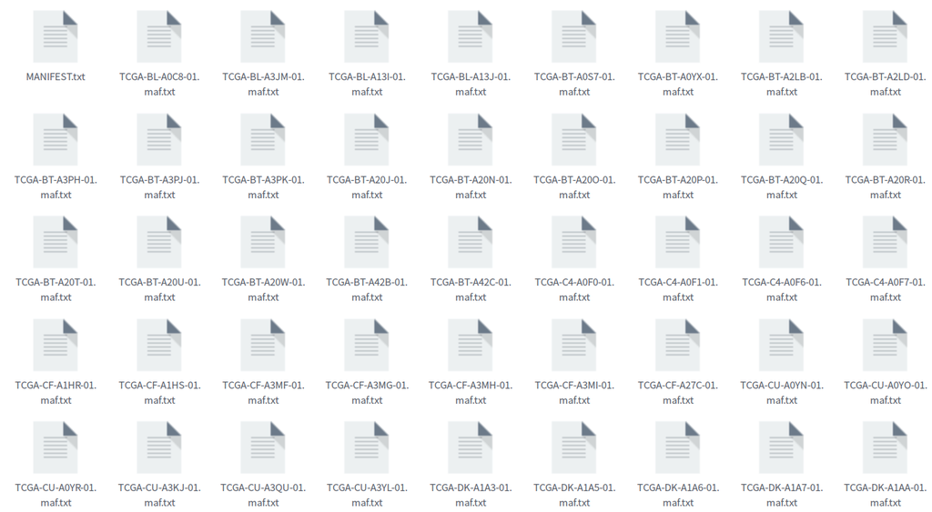

其中MANIFEST.txt文件中包含的是所有有文件的信息，长介个样子:

```
## 6e92e6639f6c1f76588ae54777f1c289 TCGA-G2-A2EF-01.maf.txt
## 4acdd7c2af2f0bd89e4562759113b8ef TCGA-FD-A3NA-01.maf.txt
## b47e7e2572ff8155cfac01a4381aaa2a TCGA-DK-A1A5-01.maf.txt
## 60232e72368959618ddc019ad4e66b9a TCGA-BT-A20U-01.maf.txt
## f98a76eddbc68f9a1969551057a68bb0 TCGA-G2-A2EJ-01.maf.txt
```

以其中一个文件为例，里面的内容是介个样子的，有用的信息其中只有第2,9两列(好惨啊，其他的都没什么用):

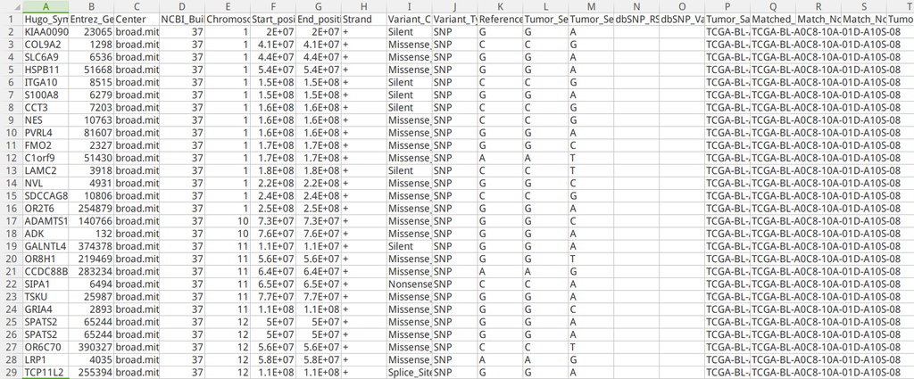

```bash
#! /usr/bin/env bash
cd PATH

if [ -d result ]
    then echo "result exists"
else
    mkdir result
fi

for file_name in `awk '{print $2}' MANIFEST.txt`
do
    sample_ID=${file_name%\-01.maf\.txt}
    `awk '{print $2"\t"$9}' $file_name | grep Missense_Mutation | sed -e "s/Missense_Mutation/${sample_ID}/" >> result/result.txt`
done
```

最终，我们得到的结果文件是长介个样子的，之所以把数据存成这个样子是为了接下去结合`{igraph}`包整理成矩阵形式:

```
## 26155    TCGA-G2-A2EF
## 84069    TCGA-G2-A2EF
## 254173   TCGA-G2-A2EF
## 23013    TCGA-G2-A2EF
## 55672    TCGA-G2-A2EF
```

接下去就是我们熟悉的R脚本部分啦，程序挺简单的就不加以说明了，最终就得到了行是gene，列是样本的突变表达谱:

```r
library(igraph)
library(dplyr)
setwd("/home/wang/Documents/学习心得/生物信息学相关/突变数据整合")
ensembl_entrez <- tbl_df(read.table("ensembl_entrez.txt", header = T, stringsAsFactors = F, sep = "\t"))
data <- tbl_df(read.table("mutation_data/result/result.txt", header = F, stringsAsFactors = F, sep = "\t"))
colnames(data) <- c("entrezgene", "sample_ID")
final_data <- data %>% left_join(ensembl_entrez, by = "entrezgene") %>% na.omit
need_data <- as.data.frame(final_data[, c(3, 2)])
mutation_net <- graph_from_edgelist(as.matrix(need_data, ncol = 2), directed = F)
mutation_adj <- as_adj(mutation_net)
sample_ID <- unique(unlist(need_data[,2]))
gene_ID <- unique(unlist(need_data[,1]))
final_adj <- mutation_adj[gene_ID, sample_ID]
write.table(matrix(c("gene", sample_ID), nrow = 1), "mutation_profile.txt", col.names = F, row.names = F, sep = "\t", quote = F, append = T)
write.table(as.matrix(final_adj, ncol = ncol(final_adj)), "mutation_profile.txt", col.names = F, row.names = T, sep = "\t", quote = F, append = T)
```

嗯，这样就结束了整个流程，不是很复杂，但是以后在使用突变数据时可能会经常用到，如果有更好的想法，可以跟我联系哟。